# Risk Factor Analysis

## Outcome Variable

**Outcome Variable:** pers_wasted624

## Predictor Variables

**Intervention Variable:** ever_wasted06

**Adjustment Set:**

unadjusted

## Stratifying Variables

The analysis was stratified on these variable(s):

- studyid
- country

## Data Summary

| studyid | country | ever_wasted06 | pers_wasted624 | n_cell | n |
| --- | --- | --- | --- | --- | --- |
| ki0047075b-MAL-ED | BANGLADESH | 0 | 0 | 180 | 240 |
| ki0047075b-MAL-ED | BANGLADESH | 0 | 1 | 5 | 240 |
| ki0047075b-MAL-ED | BANGLADESH | 1 | 0 | 42 | 240 |
| ki0047075b-MAL-ED | BANGLADESH | 1 | 1 | 13 | 240 |
| ki0047075b-MAL-ED | BRAZIL | 0 | 0 | 187 | 202 |
| ki0047075b-MAL-ED | BRAZIL | 0 | 1 | 1 | 202 |
| ki0047075b-MAL-ED | BRAZIL | 1 | 0 | 13 | 202 |
| ki0047075b-MAL-ED | BRAZIL | 1 | 1 | 1 | 202 |
| ki0047075b-MAL-ED | INDIA | 0 | 0 | 154 | 234 |
| ki0047075b-MAL-ED | INDIA | 0 | 1 | 6 | 234 |
| ki0047075b-MAL-ED | INDIA | 1 | 0 | 52 | 234 |
| ki0047075b-MAL-ED | INDIA | 1 | 1 | 22 | 234 |
| ki0047075b-MAL-ED | NEPAL | 0 | 0 | 194 | 234 |
| ki0047075b-MAL-ED | NEPAL | 0 | 1 | 0 | 234 |
| ki0047075b-MAL-ED | NEPAL | 1 | 0 | 38 | 234 |
| ki0047075b-MAL-ED | NEPAL | 1 | 1 | 2 | 234 |
| ki0047075b-MAL-ED | PERU | 0 | 0 | 252 | 264 |
| ki0047075b-MAL-ED | PERU | 0 | 1 | 2 | 264 |
| ki0047075b-MAL-ED | PERU | 1 | 0 | 10 | 264 |
| ki0047075b-MAL-ED | PERU | 1 | 1 | 0 | 264 |
| ki0047075b-MAL-ED | SOUTH AFRICA | 0 | 0 | 232 | 258 |
| ki0047075b-MAL-ED | SOUTH AFRICA | 0 | 1 | 0 | 258 |
| ki0047075b-MAL-ED | SOUTH AFRICA | 1 | 0 | 24 | 258 |
| ki0047075b-MAL-ED | SOUTH AFRICA | 1 | 1 | 2 | 258 |
| ki0047075b-MAL-ED | TANZANIA, UNITED REPUBLIC OF | 0 | 0 | 233 | 244 |
| ki0047075b-MAL-ED | TANZANIA, UNITED REPUBLIC OF | 0 | 1 | 0 | 244 |
| ki0047075b-MAL-ED | TANZANIA, UNITED REPUBLIC OF | 1 | 0 | 11 | 244 |
| ki0047075b-MAL-ED | TANZANIA, UNITED REPUBLIC OF | 1 | 1 | 0 | 244 |
| ki1000107-Serrinha-VitA | BRAZIL | 0 | 0 | 10 | 11 |
| ki1000107-Serrinha-VitA | BRAZIL | 0 | 1 | 1 | 11 |

[output cut: 126 more lines]

The following strata were considered:

- studyid: ki0047075b-MAL-ED, country: BANGLADESH
- studyid: ki0047075b-MAL-ED, country: BRAZIL
- studyid: ki0047075b-MAL-ED, country: INDIA
- studyid: ki0047075b-MAL-ED, country: NEPAL
- studyid: ki0047075b-MAL-ED, country: PERU
- studyid: ki0047075b-MAL-ED, country: SOUTH AFRICA
- studyid: ki0047075b-MAL-ED, country: TANZANIA, UNITED REPUBLIC OF
- studyid: ki1000107-Serrinha-VitA, country: BRAZIL
- studyid: ki1000108-CMC-V-BCS-2002, country: INDIA
- studyid: ki1000108-IRC, country: INDIA
- studyid: ki1000109-EE, country: PAKISTAN
- studyid: ki1000109-ResPak, country: PAKISTAN
- studyid: ki1000304-VITAMIN-A, country: INDIA
- studyid: ki1000304b-SAS-CompFeed, country: INDIA
- studyid: ki1000304b-SAS-FoodSuppl, country: INDIA
- studyid: ki1017093-NIH-Birth, country: BANGLADESH
- studyid: ki1017093b-PROVIDE, country: BANGLADESH
- studyid: ki1017093c-NIH-Crypto, country: BANGLADESH
- studyid: ki1033518-iLiNS-DYAD-G, country: GHANA
- studyid: ki1066203-TanzaniaChild2, country: TANZANIA, UNITED REPUBLIC OF
- studyid: ki1101329-Keneba, country: GAMBIA
- studyid: ki1112895-Burkina Faso Zn, country: BURKINA FASO
- studyid: ki1112895-Guatemala BSC, country: GUATEMALA
- studyid: ki1113344-GMS-Nepal, country: NEPAL
- studyid: ki1114097-CMIN, country: BANGLADESH
- studyid: ki1114097-CMIN, country: BRAZIL
- studyid: ki1114097-CMIN, country: GUINEA-BISSAU
- studyid: ki1114097-CMIN, country: PERU
- studyid: ki1114097-CONTENT, country: PERU
- studyid: ki1119695-PROBIT, country: BELARUS
- studyid: ki1126311-ZVITAMBO, country: ZIMBABWE
- studyid: ki1135781-COHORTS, country: GUATEMALA
- studyid: ki1135781-COHORTS, country: INDIA
- studyid: ki1135781-COHORTS, country: PHILIPPINES
- studyid: ki1148112-iLiNS-DOSE, country: MALAWI
- studyid: ki1148112-iLiNS-DYAD-M, country: MALAWI
- studyid: ki1148112-LCNI-5, country: MALAWI
- studyid: kiGH5241-JiVitA-3, country: BANGLADESH
- studyid: kiGH5241-JiVitA-4, country: BANGLADESH

### Dropped Strata

Some strata were dropped due to rare outcomes:

- studyid: ki0047075b-MAL-ED, country: BRAZIL
- studyid: ki0047075b-MAL-ED, country: NEPAL
- studyid: ki0047075b-MAL-ED, country: PERU
- studyid: ki0047075b-MAL-ED, country: SOUTH AFRICA
- studyid: ki0047075b-MAL-ED, country: TANZANIA, UNITED REPUBLIC OF
- studyid: ki1000107-Serrinha-VitA, country: BRAZIL
- studyid: ki1000108-CMC-V-BCS-2002, country: INDIA
- studyid: ki1112895-Burkina Faso Zn, country: BURKINA FASO
- studyid: ki1112895-Guatemala BSC, country: GUATEMALA
- studyid: ki1114097-CMIN, country: BRAZIL
- studyid: ki1114097-CMIN, country: PERU
- studyid: ki1114097-CONTENT, country: PERU
- studyid: ki1148112-iLiNS-DOSE, country: MALAWI
- studyid: ki1148112-iLiNS-DYAD-M, country: MALAWI
- studyid: ki1148112-LCNI-5, country: MALAWI

## Methods Detail

We’re interested in the causal parameters $E[Y_a]$ for all values of $a \in \mathcal{A}$. These parameters represent the mean outcome if, possibly contrary to fact, we intervened to set all units to have $A=a$. Under the randomization and positivity assumptions, these are identified by the statistical parameters $\psi_a=E_W[E_{Y|A,W}(Y|A=a,W)]$. In addition, we’re interested in the mean of $Y$, $E[Y]$ under no intervention (the observed mean). We will estimate these parameters by using SuperLearner to fit the relevant likelihood factors – $E_{Y|A,W}(Y|A=a,W)$ and $p(A=a|W)$, and then updating our likelihood fit using a joint TMLE.

For unadjusted analyses ($W=\{\}$), initial likelihoods were estimated using Lrnr_glm to estimate the simple $E(Y|A)$ and Lrnr_mean to estimate $p(A)$. For adjusted analyses, a small library containing Lrnr_glmnet, Lrnr_xgboost, and Lrnr_mean was used.

Having estimated these parameters, we will then use the delta method to estimate relative risks and attributable risks relative to a prespecified baseline level of $A$.

# Results Detail

## Results Plots

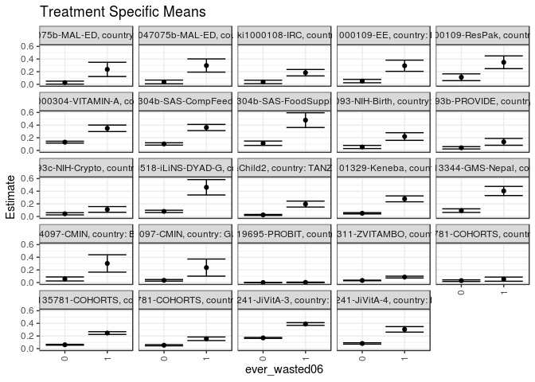

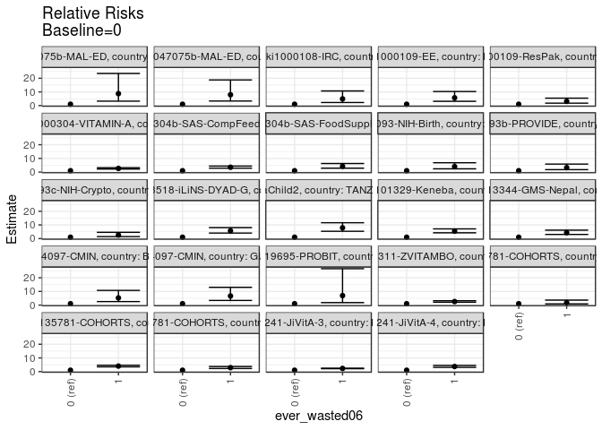

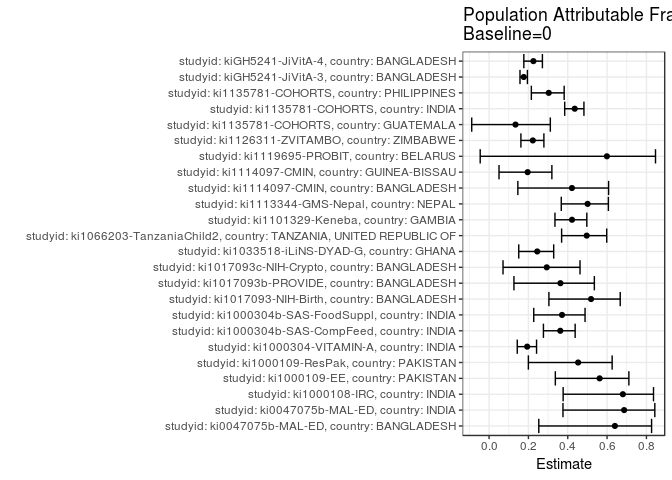

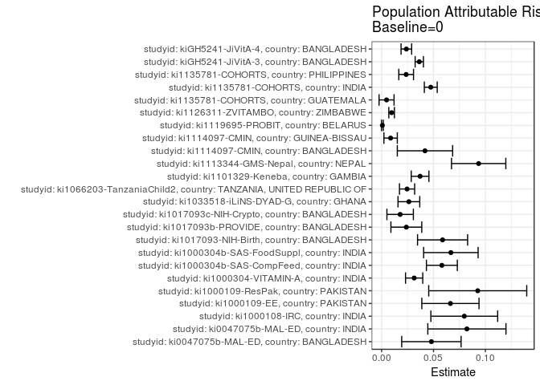

## Results Table

### Parameter: TSM

| studyid | country | intervention_level | baseline_level | estimate | ci_lower | ci_upper |
| --- | --- | --- | --- | --- | --- | --- |
| ki0047075b-MAL-ED | BANGLADESH | 0 | NA | 0.0270270 | 0.0036107 | 0.0504433 |
| ki0047075b-MAL-ED | BANGLADESH | 1 | NA | 0.2363636 | 0.1238495 | 0.3488778 |
| ki0047075b-MAL-ED | INDIA | 0 | NA | 0.0375000 | 0.0079992 | 0.0670008 |
| ki0047075b-MAL-ED | INDIA | 1 | NA | 0.2972973 | 0.1929350 | 0.4016596 |
| ki1000108-IRC | INDIA | 0 | NA | 0.0374332 | 0.0101935 | 0.0646728 |
| ki1000108-IRC | INDIA | 1 | NA | 0.1838565 | 0.1329529 | 0.2347601 |
| ki1000109-EE | PAKISTAN | 0 | NA | 0.0516605 | 0.0252724 | 0.0780486 |
| ki1000109-EE | PAKISTAN | 1 | NA | 0.2941176 | 0.2055739 | 0.3826613 |
| ki1000109-ResPak | PAKISTAN | 0 | NA | 0.1119403 | 0.0584347 | 0.1654459 |
| ki1000109-ResPak | PAKISTAN | 1 | NA | 0.3488372 | 0.2478784 | 0.4497960 |
| ki1000304-VITAMIN-A | INDIA | 0 | NA | 0.1303907 | 0.1155216 | 0.1452598 |
| ki1000304-VITAMIN-A | INDIA | 1 | NA | 0.3495441 | 0.2980088 | 0.4010793 |
| ki1000304b-SAS-CompFeed | INDIA | 0 | NA | 0.1022945 | 0.0836988 | 0.1208901 |
| ki1000304b-SAS-CompFeed | INDIA | 1 | NA | 0.3621262 | 0.3131639 | 0.4110886 |
| ki1000304b-SAS-FoodSuppl | INDIA | 0 | NA | 0.1132075 | 0.0783383 | 0.1480768 |
| ki1000304b-SAS-FoodSuppl | INDIA | 1 | NA | 0.4788732 | 0.3625250 | 0.5952215 |
| ki1017093-NIH-Birth | BANGLADESH | 0 | NA | 0.0545455 | 0.0300201 | 0.0790708 |
| ki1017093-NIH-Birth | BANGLADESH | 1 | NA | 0.2197802 | 0.1595604 | 0.2800001 |
| ki1017093b-PROVIDE | BANGLADESH | 0 | NA | 0.0418502 | 0.0234152 | 0.0602852 |
| ki1017093b-PROVIDE | BANGLADESH | 1 | NA | 0.1354839 | 0.0815614 | 0.1894063 |
| ki1017093c-NIH-Crypto | BANGLADESH | 0 | NA | 0.0430712 | 0.0258401 | 0.0603022 |
| ki1017093c-NIH-Crypto | BANGLADESH | 1 | NA | 0.1117021 | 0.0666433 | 0.1567610 |
| ki1033518-iLiNS-DYAD-G | GHANA | 0 | NA | 0.0810502 | 0.0629681 | 0.0991324 |
| ki1033518-iLiNS-DYAD-G | GHANA | 1 | NA | 0.4615385 | 0.3402824 | 0.5827946 |
| ki1066203-TanzaniaChild2 | TANZANIA, UNITED REPUBLIC OF | 0 | NA | 0.0248937 | 0.0173674 | 0.0324201 |
| ki1066203-TanzaniaChild2 | TANZANIA, UNITED REPUBLIC OF | 1 | NA | 0.1963636 | 0.1494007 | 0.2433266 |
| ki1101329-Keneba | GAMBIA | 0 | NA | 0.0508475 | 0.0407771 | 0.0609178 |
| ki1101329-Keneba | GAMBIA | 1 | NA | 0.2788732 | 0.2322135 | 0.3255330 |
| ki1113344-GMS-Nepal | NEPAL | 0 | NA | 0.0931373 | 0.0649130 | 0.1213615 |
| ki1113344-GMS-Nepal | NEPAL | 1 | NA | 0.4034091 | 0.3308695 | 0.4759487 |
| ki1114097-CMIN | BANGLADESH | 0 | NA | 0.0574163 | 0.0258142 | 0.0890184 |
| ki1114097-CMIN | BANGLADESH | 1 | NA | 0.3023256 | 0.1647817 | 0.4398694 |
| ki1114097-CMIN | GUINEA-BISSAU | 0 | NA | 0.0356295 | 0.0231019 | 0.0481570 |
| ki1114097-CMIN | GUINEA-BISSAU | 1 | NA | 0.2368421 | 0.1015913 | 0.3720929 |
| ki1119695-PROBIT | BELARUS | 0 | NA | 0.0004875 | 0.0000008 | 0.0009742 |
| ki1119695-PROBIT | BELARUS | 1 | NA | 0.0033800 | 0.0000091 | 0.0067509 |
| ki1126311-ZVITAMBO | ZIMBABWE | 0 | NA | 0.0336869 | 0.0294528 | 0.0379210 |
| ki1126311-ZVITAMBO | ZIMBABWE | 1 | NA | 0.0869565 | 0.0728873 | 0.1010257 |
| ki1135781-COHORTS | GUATEMALA | 0 | NA | 0.0308123 | 0.0181298 | 0.0434949 |
| ki1135781-COHORTS | GUATEMALA | 1 | NA | 0.0540541 | 0.0214515 | 0.0866566 |
| ki1135781-COHORTS | INDIA | 0 | NA | 0.0614015 | 0.0542922 | 0.0685108 |
| ki1135781-COHORTS | INDIA | 1 | NA | 0.2468397 | 0.2250396 | 0.2686397 |
| ki1135781-COHORTS | PHILIPPINES | 0 | NA | 0.0543478 | 0.0446867 | 0.0640089 |
| ki1135781-COHORTS | PHILIPPINES | 1 | NA | 0.1562500 | 0.1281146 | 0.1843854 |
| kiGH5241-JiVitA-3 | BANGLADESH | 0 | NA | 0.1696541 | 0.1620038 | 0.1773044 |
| kiGH5241-JiVitA-3 | BANGLADESH | 1 | NA | 0.3896934 | 0.3680634 | 0.4113233 |
| kiGH5241-JiVitA-4 | BANGLADESH | 0 | NA | 0.0820147 | 0.0714681 | 0.0925613 |
| kiGH5241-JiVitA-4 | BANGLADESH | 1 | NA | 0.3048327 | 0.2611744 | 0.3484910 |

### Parameter: E(Y)

| studyid | country | intervention_level | baseline_level | estimate | ci_lower | ci_upper |
| --- | --- | --- | --- | --- | --- | --- |
| ki0047075b-MAL-ED | BANGLADESH | NA | NA | 0.0750000 | 0.0416074 | 0.1083926 |
| ki0047075b-MAL-ED | INDIA | NA | NA | 0.1196581 | 0.0779840 | 0.1613323 |
| ki1000108-IRC | INDIA | NA | NA | 0.1170732 | 0.0859146 | 0.1482317 |
| ki1000109-EE | PAKISTAN | NA | NA | 0.1179625 | 0.0851837 | 0.1507412 |
| ki1000109-ResPak | PAKISTAN | NA | NA | 0.2045455 | 0.1511224 | 0.2579685 |
| ki1000304-VITAMIN-A | INDIA | NA | NA | 0.1617391 | 0.1466878 | 0.1767905 |
| ki1000304b-SAS-CompFeed | INDIA | NA | NA | 0.1603563 | 0.1395035 | 0.1812092 |
| ki1000304b-SAS-FoodSuppl | INDIA | NA | NA | 0.1799486 | 0.1417254 | 0.2181718 |
| ki1017093-NIH-Birth | BANGLADESH | NA | NA | 0.1132813 | 0.0858017 | 0.1407608 |
| ki1017093b-PROVIDE | BANGLADESH | NA | NA | 0.0656814 | 0.0459906 | 0.0853723 |
| ki1017093c-NIH-Crypto | BANGLADESH | NA | NA | 0.0609418 | 0.0434802 | 0.0784034 |
| ki1033518-iLiNS-DYAD-G | GHANA | NA | NA | 0.1073326 | 0.0875449 | 0.1271203 |
| ki1066203-TanzaniaChild2 | TANZANIA, UNITED REPUBLIC OF | NA | NA | 0.0494277 | 0.0397346 | 0.0591208 |
| ki1101329-Keneba | GAMBIA | NA | NA | 0.0879121 | 0.0760335 | 0.0997907 |
| ki1113344-GMS-Nepal | NEPAL | NA | NA | 0.1866438 | 0.1550166 | 0.2182711 |
| ki1114097-CMIN | BANGLADESH | NA | NA | 0.0992063 | 0.0622241 | 0.1361886 |
| ki1114097-CMIN | GUINEA-BISSAU | NA | NA | 0.0443182 | 0.0307131 | 0.0579233 |
| ki1119695-PROBIT | BELARUS | NA | NA | 0.0012159 | 0.0002433 | 0.0021885 |
| ki1126311-ZVITAMBO | ZIMBABWE | NA | NA | 0.0433251 | 0.0390011 | 0.0476491 |
| ki1135781-COHORTS | GUATEMALA | NA | NA | 0.0355951 | 0.0234770 | 0.0477132 |
| ki1135781-COHORTS | INDIA | NA | NA | 0.1087695 | 0.1008135 | 0.1167256 |
| ki1135781-COHORTS | PHILIPPINES | NA | NA | 0.0780116 | 0.0679971 | 0.0880261 |
| kiGH5241-JiVitA-3 | BANGLADESH | NA | NA | 0.2059588 | 0.1983834 | 0.2135343 |
| kiGH5241-JiVitA-4 | BANGLADESH | NA | NA | 0.1058706 | 0.0951082 | 0.1166330 |

### Parameter: RR

| studyid | country | intervention_level | baseline_level | estimate | ci_lower | ci_upper |
| --- | --- | --- | --- | --- | --- | --- |
| ki0047075b-MAL-ED | BANGLADESH | 0 | 0 | 1.000000 | 1.0000000 | 1.000000 |
| ki0047075b-MAL-ED | BANGLADESH | 1 | 0 | 8.745454 | 3.2542894 | 23.502204 |
| ki0047075b-MAL-ED | INDIA | 0 | 0 | 1.000000 | 1.0000000 | 1.000000 |
| ki0047075b-MAL-ED | INDIA | 1 | 0 | 7.927928 | 3.3499192 | 18.762256 |
| ki1000108-IRC | INDIA | 0 | 0 | 1.000000 | 1.0000000 | 1.000000 |
| ki1000108-IRC | INDIA | 1 | 0 | 4.911595 | 2.2547088 | 10.699283 |
| ki1000109-EE | PAKISTAN | 0 | 0 | 1.000000 | 1.0000000 | 1.000000 |
| ki1000109-EE | PAKISTAN | 1 | 0 | 5.693277 | 3.1467625 | 10.300557 |
| ki1000109-ResPak | PAKISTAN | 0 | 0 | 1.000000 | 1.0000000 | 1.000000 |
| ki1000109-ResPak | PAKISTAN | 1 | 0 | 3.116279 | 1.7822289 | 5.448905 |
| ki1000304-VITAMIN-A | INDIA | 0 | 0 | 1.000000 | 1.0000000 | 1.000000 |
| ki1000304-VITAMIN-A | INDIA | 1 | 0 | 2.680745 | 2.2248835 | 3.230008 |
| ki1000304b-SAS-CompFeed | INDIA | 0 | 0 | 1.000000 | 1.0000000 | 1.000000 |
| ki1000304b-SAS-CompFeed | INDIA | 1 | 0 | 3.540038 | 2.8376671 | 4.416257 |
| ki1000304b-SAS-FoodSuppl | INDIA | 0 | 0 | 1.000000 | 1.0000000 | 1.000000 |
| ki1000304b-SAS-FoodSuppl | INDIA | 1 | 0 | 4.230047 | 2.8573937 | 6.262104 |
| ki1017093-NIH-Birth | BANGLADESH | 0 | 0 | 1.000000 | 1.0000000 | 1.000000 |
| ki1017093-NIH-Birth | BANGLADESH | 1 | 0 | 4.029304 | 2.3798879 | 6.821872 |
| ki1017093b-PROVIDE | BANGLADESH | 0 | 0 | 1.000000 | 1.0000000 | 1.000000 |
| ki1017093b-PROVIDE | BANGLADESH | 1 | 0 | 3.237351 | 1.7879808 | 5.861609 |
| ki1017093c-NIH-Crypto | BANGLADESH | 0 | 0 | 1.000000 | 1.0000000 | 1.000000 |
| ki1017093c-NIH-Crypto | BANGLADESH | 1 | 0 | 2.593432 | 1.4694036 | 4.577292 |
| ki1033518-iLiNS-DYAD-G | GHANA | 0 | 0 | 1.000000 | 1.0000000 | 1.000000 |
| ki1033518-iLiNS-DYAD-G | GHANA | 1 | 0 | 5.694475 | 4.0342860 | 8.037864 |
| ki1066203-TanzaniaChild2 | TANZANIA, UNITED REPUBLIC OF | 0 | 0 | 1.000000 | 1.0000000 | 1.000000 |
| ki1066203-TanzaniaChild2 | TANZANIA, UNITED REPUBLIC OF | 1 | 0 | 7.888071 | 5.3647739 | 11.598189 |
| ki1101329-Keneba | GAMBIA | 0 | 0 | 1.000000 | 1.0000000 | 1.000000 |
| ki1101329-Keneba | GAMBIA | 1 | 0 | 5.484507 | 4.2319493 | 7.107793 |
| ki1113344-GMS-Nepal | NEPAL | 0 | 0 | 1.000000 | 1.0000000 | 1.000000 |
| ki1113344-GMS-Nepal | NEPAL | 1 | 0 | 4.331340 | 3.0450085 | 6.161068 |
| ki1114097-CMIN | BANGLADESH | 0 | 0 | 1.000000 | 1.0000000 | 1.000000 |
| ki1114097-CMIN | BANGLADESH | 1 | 0 | 5.265504 | 2.5781863 | 10.753890 |
| ki1114097-CMIN | GUINEA-BISSAU | 0 | 0 | 1.000000 | 1.0000000 | 1.000000 |
| ki1114097-CMIN | GUINEA-BISSAU | 1 | 0 | 6.647368 | 3.3993972 | 12.998630 |
| ki1119695-PROBIT | BELARUS | 0 | 0 | 1.000000 | 1.0000000 | 1.000000 |
| ki1119695-PROBIT | BELARUS | 1 | 0 | 6.932963 | 1.8068114 | 26.602654 |
| ki1126311-ZVITAMBO | ZIMBABWE | 0 | 0 | 1.000000 | 1.0000000 | 1.000000 |
| ki1126311-ZVITAMBO | ZIMBABWE | 1 | 0 | 2.581314 | 2.1031133 | 3.168246 |
| ki1135781-COHORTS | GUATEMALA | 0 | 0 | 1.000000 | 1.0000000 | 1.000000 |
| ki1135781-COHORTS | GUATEMALA | 1 | 0 | 1.754300 | 0.8452357 | 3.641076 |
| ki1135781-COHORTS | INDIA | 0 | 0 | 1.000000 | 1.0000000 | 1.000000 |
| ki1135781-COHORTS | INDIA | 1 | 0 | 4.020091 | 3.4753064 | 4.650276 |
| ki1135781-COHORTS | PHILIPPINES | 0 | 0 | 1.000000 | 1.0000000 | 1.000000 |
| ki1135781-COHORTS | PHILIPPINES | 1 | 0 | 2.875000 | 2.2322786 | 3.702775 |
| kiGH5241-JiVitA-3 | BANGLADESH | 0 | 0 | 1.000000 | 1.0000000 | 1.000000 |
| kiGH5241-JiVitA-3 | BANGLADESH | 1 | 0 | 2.296987 | 2.1413382 | 2.463950 |
| kiGH5241-JiVitA-4 | BANGLADESH | 0 | 0 | 1.000000 | 1.0000000 | 1.000000 |
| kiGH5241-JiVitA-4 | BANGLADESH | 1 | 0 | 3.716805 | 3.0752062 | 4.492265 |

### Parameter: PAR

| studyid | country | intervention_level | baseline_level | estimate | ci_lower | ci_upper |
| --- | --- | --- | --- | --- | --- | --- |
| ki0047075b-MAL-ED | BANGLADESH | 0 | NA | 0.0479730 | 0.0193712 | 0.0765747 |
| ki0047075b-MAL-ED | INDIA | 0 | NA | 0.0821581 | 0.0445166 | 0.1197996 |
| ki1000108-IRC | INDIA | 0 | NA | 0.0796400 | 0.0474529 | 0.1118271 |
| ki1000109-EE | PAKISTAN | 0 | NA | 0.0663019 | 0.0387529 | 0.0938510 |
| ki1000109-ResPak | PAKISTAN | 0 | NA | 0.0926052 | 0.0453886 | 0.1398217 |
| ki1000304-VITAMIN-A | INDIA | 0 | NA | 0.0313485 | 0.0230597 | 0.0396373 |
| ki1000304b-SAS-CompFeed | INDIA | 0 | NA | 0.0580619 | 0.0431660 | 0.0729578 |
| ki1000304b-SAS-FoodSuppl | INDIA | 0 | NA | 0.0667410 | 0.0404925 | 0.0929896 |
| ki1017093-NIH-Birth | BANGLADESH | 0 | NA | 0.0587358 | 0.0346265 | 0.0828451 |
| ki1017093b-PROVIDE | BANGLADESH | 0 | NA | 0.0238312 | 0.0089693 | 0.0386931 |
| ki1017093c-NIH-Crypto | BANGLADESH | 0 | NA | 0.0178707 | 0.0051183 | 0.0306230 |
| ki1033518-iLiNS-DYAD-G | GHANA | 0 | NA | 0.0262824 | 0.0158058 | 0.0367590 |
| ki1066203-TanzaniaChild2 | TANZANIA, UNITED REPUBLIC OF | 0 | NA | 0.0245339 | 0.0172182 | 0.0318496 |
| ki1101329-Keneba | GAMBIA | 0 | NA | 0.0370646 | 0.0285407 | 0.0455885 |
| ki1113344-GMS-Nepal | NEPAL | 0 | NA | 0.0935066 | 0.0673566 | 0.1196565 |
| ki1114097-CMIN | BANGLADESH | 0 | NA | 0.0417901 | 0.0151476 | 0.0684325 |
| ki1114097-CMIN | GUINEA-BISSAU | 0 | NA | 0.0086887 | 0.0022302 | 0.0151473 |
| ki1119695-PROBIT | BELARUS | 0 | NA | 0.0007284 | -0.0001416 | 0.0015983 |
| ki1126311-ZVITAMBO | ZIMBABWE | 0 | NA | 0.0096382 | 0.0069444 | 0.0123320 |
| ki1135781-COHORTS | GUATEMALA | 0 | NA | 0.0047828 | -0.0024422 | 0.0120078 |
| ki1135781-COHORTS | INDIA | 0 | NA | 0.0473680 | 0.0411570 | 0.0535791 |
| ki1135781-COHORTS | PHILIPPINES | 0 | NA | 0.0236638 | 0.0165713 | 0.0307563 |
| kiGH5241-JiVitA-3 | BANGLADESH | 0 | NA | 0.0363047 | 0.0323128 | 0.0402966 |
| kiGH5241-JiVitA-4 | BANGLADESH | 0 | NA | 0.0238559 | 0.0187572 | 0.0289547 |

### Parameter: PAF

| studyid | country | intervention_level | baseline_level | estimate | ci_lower | ci_upper |
| --- | --- | --- | --- | --- | --- | --- |
| ki0047075b-MAL-ED | BANGLADESH | 0 | NA | 0.6396396 | 0.2527566 | 0.8262151 |
| ki0047075b-MAL-ED | INDIA | 0 | NA | 0.6866071 | 0.3757083 | 0.8426776 |
| ki1000108-IRC | INDIA | 0 | NA | 0.6802585 | 0.3765411 | 0.8360202 |
| ki1000109-EE | PAKISTAN | 0 | NA | 0.5620597 | 0.3369023 | 0.7107640 |
| ki1000109-ResPak | PAKISTAN | 0 | NA | 0.4527363 | 0.1997756 | 0.6257331 |
| ki1000304-VITAMIN-A | INDIA | 0 | NA | 0.1938212 | 0.1432880 | 0.2413737 |
| ki1000304b-SAS-CompFeed | INDIA | 0 | NA | 0.3620804 | 0.2763681 | 0.4376403 |
| ki1000304b-SAS-FoodSuppl | INDIA | 0 | NA | 0.3708895 | 0.2270307 | 0.4879744 |
| ki1017093-NIH-Birth | BANGLADESH | 0 | NA | 0.5184953 | 0.3042028 | 0.6667897 |
| ki1017093b-PROVIDE | BANGLADESH | 0 | NA | 0.3628304 | 0.1264232 | 0.5352611 |
| ki1017093c-NIH-Crypto | BANGLADESH | 0 | NA | 0.2932414 | 0.0708881 | 0.4623815 |
| ki1033518-iLiNS-DYAD-G | GHANA | 0 | NA | 0.2448687 | 0.1508007 | 0.3285165 |
| ki1066203-TanzaniaChild2 | TANZANIA, UNITED REPUBLIC OF | 0 | NA | 0.4963602 | 0.3688026 | 0.5981399 |
| ki1101329-Keneba | GAMBIA | 0 | NA | 0.4216102 | 0.3349722 | 0.4969612 |
| ki1113344-GMS-Nepal | NEPAL | 0 | NA | 0.5009894 | 0.3670700 | 0.6065732 |
| ki1114097-CMIN | BANGLADESH | 0 | NA | 0.4212440 | 0.1463035 | 0.6076375 |
| ki1114097-CMIN | GUINEA-BISSAU | 0 | NA | 0.1960534 | 0.0505496 | 0.3192586 |
| ki1119695-PROBIT | BELARUS | 0 | NA | 0.5990331 | -0.0451102 | 0.8461650 |
| ki1126311-ZVITAMBO | ZIMBABWE | 0 | NA | 0.2224619 | 0.1618396 | 0.2786995 |
| ki1135781-COHORTS | GUATEMALA | 0 | NA | 0.1343662 | -0.0882265 | 0.3114285 |
| ki1135781-COHORTS | INDIA | 0 | NA | 0.4354899 | 0.3844691 | 0.4822816 |
| ki1135781-COHORTS | PHILIPPINES | 0 | NA | 0.3033367 | 0.2149251 | 0.3817918 |
| kiGH5241-JiVitA-3 | BANGLADESH | 0 | NA | 0.1762716 | 0.1571802 | 0.1949305 |
| kiGH5241-JiVitA-4 | BANGLADESH | 0 | NA | 0.2253310 | 0.1766499 | 0.2711338 |